# Er det høyde som bestemmer inntekt?

# Huxreg

```r
huxreg (list
  ("Modell1" = lm1, "Modell2" = lm2, "Modell3" = lm3),
       error_format = "[{statistic}]",
       note = "Regresjonstabell 3: {stars}.T statistics in brackets."
)
```

```
      ─────────────────────────────────────────────────────────────────────────────────────────────────────
                                        Modell1                  Modell2                  Modell3
                               ────────────────────────────────────────────────────────────────────────────
        (Intercept)                    -1361000.990 ***         -1466873.555 ***         -1286217.908 ***
                                           [-14.413]                [-15.139]                 [-9.722]
        hoyde_cm                          10047.860 ***            11430.259 ***             9413.347 ***
                                            [18.175]                 [18.308]                  [7.951]
        vekt_kg                                                    -1518.381 ***             2039.260
                                                                     [-4.737]                  [1.131]
        BMI                                                                               -538714.354 *
                                                                                              [-2.005]
                               ────────────────────────────────────────────────────────────────────────────
        N                                  6645                     6645                     6645
        R2                                    0.047                    0.051                    0.051
        logLik                           -96177.211               -96166.004               -96163.994
        AIC                              192360.423               192340.008               192337.987
      ─────────────────────────────────────────────────────────────────────────────────────────────────────
        Regresjonstabell 3: *** p < 0.001; ** p < 0.01; * p < 0.05.T statistics in brackets.

Column names: names, Modell1, Modell2, Modell3
```

# Interaksjon

## Modell 4

Modell 4 fire inneholder en interaksjon mellom variablene *“hoyde_cm”* og *“sex”*.

```r
Modell4 <- "inntekt ~ sex*hoyde_cm + vekt_kg + I(vekt_kg^2) + BMI + I(BMI^2)"
lm4 <- lm(Modell4, data = hoyde)
summary(lm4)
```

```
Call:
lm(formula = Modell4, data = hoyde)

Residuals:
    Min      1Q  Median      3Q     Max
-838791 -246526  -91148  127011 2671450

Coefficients:
                      Estimate  Std. Error t value    Pr(>|t|)
(Intercept)        -1483862.35   298212.30  -4.976 0.000000665 ***
sexfemale           1013185.90   267052.10   3.794     0.00015 ***
hoyde_cm               9605.99     2224.53   4.318 0.000015950 ***
vekt_kg                7666.44     4523.70   1.695     0.09017 .
I(vekt_kg^2)            -41.62       15.13  -2.752     0.00594 **
BMI                 -574174.60   743591.63  -0.772     0.44004
I(BMI^2)             508980.64   335754.40   1.516     0.12958
sexfemale:hoyde_cm    -6597.83     1566.60  -4.212 0.000025683 ***
---
Signif. codes:  0 ‘***’ 0.001 ‘**’ 0.01 ‘*’ 0.05 ‘.’ 0.1 ‘ ’ 1

Residual standard error: 458400 on 6903 degrees of freedom
  (95 observations deleted due to missingness)
Multiple R-squared:  0.06121,   Adjusted R-squared:  0.06026
F-statistic:  64.3 on 7 and 6903 DF,  p-value: < 2.2e-16
```

## Modell 5

Modell 5 inneholder interaksjon mellom flere variabler.

```r
Modell5 <- "inntekt ~ sex*(hoyde_cm + vekt_kg + I(vekt_kg^2)) + BMI + I(BMI^2)"
lm5 <- lm(Modell5, data = hoyde)
summary(lm5)
```

```
Call:
lm(formula = Modell5, data = hoyde)

Residuals:
    Min      1Q  Median      3Q     Max
-817997 -247845  -91322  125631 2682274

Coefficients:
                          Estimate  Std. Error t value    Pr(>|t|)
(Intercept)            -1735256.55   352726.42  -4.920 0.000000888 ***
sexfemale               1235228.84   286424.66   4.313 0.000016361 ***
hoyde_cm                   9211.45     2510.05   3.670    0.000245 ***
vekt_kg                   14077.13     5211.47   2.701    0.006926 **
I(vekt_kg^2)                -74.61       20.58  -3.625    0.000291 ***
BMI                     -541074.91   859723.71  -0.629    0.529135
I(BMI^2)                 651407.12   340295.70   1.914    0.055631 .
sexfemale:hoyde_cm        -5387.86     1635.05  -3.295    0.000988 ***
sexfemale:vekt_kg         -8222.31     3379.45  -2.433    0.014998 *
sexfemale:I(vekt_kg^2)       35.98       17.81   2.021    0.043359 *
---
Signif. codes:  0 ‘***’ 0.001 ‘**’ 0.01 ‘*’ 0.05 ‘.’ 0.1 ‘ ’ 1

Residual standard error: 458200 on 6901 degrees of freedom
  (95 observations deleted due to missingness)
Multiple R-squared:  0.06222,   Adjusted R-squared:  0.06099
F-statistic: 50.87 on 9 and 6901 DF,  p-value: < 2.2e-16
```

# Test av koeffisientene

```r
linearHypothesis(lm4, c("sexfemale = 0", "sexfemale:hoyde_cm = 0"))
```

```
Linear hypothesis test

Hypothesis:
sexfemale = 0
sexfemale:hoyde_cm = 0

Model 1: restricted model
Model 2: inntekt ~ sex * hoyde_cm + vekt_kg + I(vekt_kg^2) + BMI + I(BMI^2)

  Res.Df              RSS Df      Sum of Sq      F    Pr(>F)
1   6905 1464054711649141
2   6903 1450383223210038  2 13671488439103 32.534 8.644e-15 ***
---
Signif. codes:  0 ‘***’ 0.001 ‘**’ 0.01 ‘*’ 0.05 ‘.’ 0.1 ‘ ’ 1
```

# Begrensing

## Modell 6

```r
Modell6 <- "inntekt ~ sex*hoyde_cm + vekt_kg + I(vekt_kg^2) + BMI + I(BMI^2)"
lm6 <- lm(Modell6, data = hoyde_begr)
summary(lm6)
```

[output not shown]

# Legge til residualene til datasettet

```r
# Bruk verdiene fra begrenset datasett
hoyde_begr <- hoyde %>%
  add_residuals(lm6)
hoyde_begr %>%
  head(n=10)
```

| income | height | weight | age | marital | sex | education | afqt | inntekt | hoyde_cm | vekt_kg | BMI | married | resid |
| --- | --- | --- | --- | --- | --- | --- | --- | --- | --- | --- | --- | --- | --- |
| 19000 | 60 | 155 | 53 | married | female | 13 | 6.841 | 159980 | 152.40 | 70.370 | 0.2132088 | TRUE | -61872.48 |
| 35000 | 70 | 156 | 51 | married | female | 10 | 49.444 | 294700 | 177.80 | 70.824 | 0.1586709 | TRUE | -25363.55 |
| 105000 | 65 | 195 | 52 | married | male | 16 | 99.393 | 884100 | 165.10 | 88.530 | 0.2875324 | TRUE | 552549.84 |
| 40000 | 63 | 197 | 54 | married | female | 14 | 44.022 | 336800 | 160.02 | 89.438 | 0.3123889 | TRUE | 103094.02 |
| 75000 | 66 | 190 | 49 | married | male | 14 | 59.683 | 631500 | 167.64 | 86.260 | 0.2647668 | TRUE | 269766.26 |
| 102000 | 68 | 200 | 49 | divorced | female | 18 | 98.798 | 858840 | 172.72 | 90.800 | 0.2763672 | FALSE | 576818.45 |
| 0 | 74 | 225 | 48 | married | male | 16 | 82.260 | 0 | 187.96 | 102.150 | 0.2953560 | TRUE | -545288.22 |
| 70000 | 64 | 160 | 54 | divorced | female | 12 | 50.283 | 589400 | 162.56 | 72.640 | 0.1996753 | FALSE | 328167.82 |
| 60000 | 69 | 162 | 55 | divorced | male | 12 | 89.669 | 505200 | 175.26 | 73.548 | 0.1761068 | FALSE | 52154.18 |
| 150000 | 69 | 194 | 54 | divorced | male | 13 | 95.977 | 1263000 | 175.26 | 88.076 | 0.2525513 | FALSE | 823526.90 |

# Plot av samtlige observasjoner

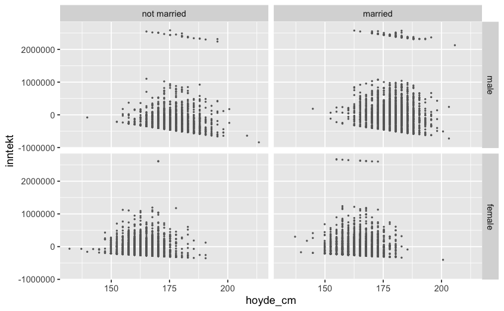

```r
ggplot(data = hoyde_begr, mapping = aes(x = hoyde_cm, y = inntekt)) +
  geom_point(
    data = hoyde_begr,
    mapping = aes(x = hoyde_cm, y = resid),
    colour = "grey40",
    size = 0.3
    ) +
  facet_grid(sex ~ factor(married, labels = c("not married", "married")))
```

## Modell 7 på redusert datasett

```r
lm7 <- hoyde %>%
  filter(income >0, income < 300000) %>%
  filter(complete.cases(.) == TRUE) %>%
  lm(mod7, data = .)
```

[output not shown]

```r
summary(lm7)
```

```
Call:
lm(formula = mod7, data = .)

Residuals:
     Min       1Q   Median       3Q      Max
-279.819  -39.601    0.899   41.711  230.105

Coefficients:
                       Estimate Std. Error t value Pr(>|t|)
(Intercept)           106.68768   32.47402   3.285  0.00103 **
sexfemale             -80.33900   45.36066  -1.771  0.07660 .
education               7.97504    0.68254  11.684  < 2e-16 ***
afqt                    0.66405    0.05793  11.464  < 2e-16 ***
age                    -0.85418    0.61394  -1.391  0.16419
marriedTRUE            34.35031    2.85321  12.039  < 2e-16 ***
sexfemale:education     0.91711    0.91753   1.000  0.31758
sexfemale:afqt         -0.20054    0.08210  -2.443  0.01462 *
sexfemale:age           1.20999    0.86016   1.407  0.15958
sexfemale:marriedTRUE -37.89356    3.97439  -9.534  < 2e-16 ***
---
Signif. codes:  0 ‘***’ 0.001 ‘**’ 0.01 ‘*’ 0.05 ‘.’ 0.1 ‘ ’ 1

Residual standard error: 66.72 on 4861 degrees of freedom
Multiple R-squared:  0.2653,    Adjusted R-squared:  0.2639
F-statistic:   195 on 9 and 4861 DF,  p-value: < 2.2e-16
```

Bør *age* være med i modellen?

```r
# robyst standard errors
linearHypothesis(
  lm7,
  c("age = 0", "sexfemale:age"),
  white.adjust = "hc3"
  )
```

```
Linear hypothesis test

Hypothesis:
age = 0
sexfemale:age = 0

Model 1: restricted model
Model 2: sqrt(income) ~ sex * (education + afqt + age + married)

Note: Coefficient covariance matrix supplied.

  Res.Df Df      F Pr(>F)
1   4863
2   4861  2 1.1216 0.3258
```

Ser at vi ikke kan forkaste H0 om at *age* koeffisientene er lik 0. Bør derfor trolig droppe *age* fra modellen.

```r
# robust standard errors
lmtest::coeftest(
  lm8,
  vcov = sandwich::vcovHC, type = "HC3"
)
```

```
t test of coefficients:

                        Estimate Std. Error t value  Pr(>|t|)
(Intercept)            62.887874   8.389245  7.4962 7.759e-14 ***
sexfemale             -18.386491  11.408622 -1.6116   0.10711
education               7.988504   0.718425 11.1195 < 2.2e-16 ***
afqt                    0.663643   0.058626 11.3199 < 2.2e-16 ***
marriedTRUE            34.135888   2.929092 11.6541 < 2.2e-16 ***
sexfemale:education     0.912114   0.955949  0.9541   0.34006
sexfemale:afqt         -0.200926   0.082860 -2.4249   0.01535 *
sexfemale:marriedTRUE -37.667435   3.975194 -9.4756 < 2.2e-16 ***
---
Signif. codes:  0 ‘***’ 0.001 ‘**’ 0.01 ‘*’ 0.05 ‘.’ 0.1 ‘ ’ 1
```

Sjekker om det er noen sammenheng mellom residualene (uforklarte forskjeller i inntekt) og hoyde i centimeter.

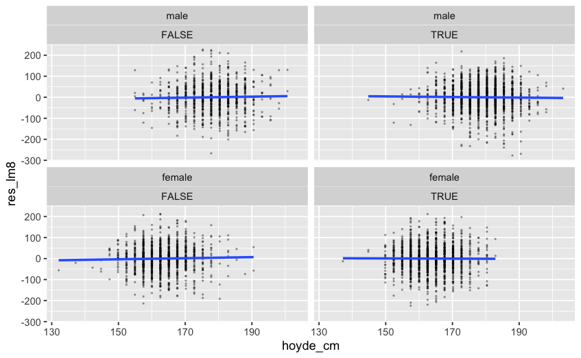

Justerer vi for kjente faktorer som kjønn, utdanning, evner og sivilstatus ser det ikke ut til å være noen som helst sammenheng mellom høyde og inntekt. Dette gjelder for grupene gifte/ugifte menn og gifte/ugifte kvinner. Det kan selvsagt tenkes at det finnes undergrupper hvor høyde har betydning for inntekt, men å avgjøre om dette er tilfelle vil kreve nærmere undersøkelser.

# Konklusjon

Selv om både Judge and Cable (2004b) og Eli Kvisvik (2008a) har gode argumenter for sammenhengen mellom høyde og inntekt, viser statistikken utført at vi burde inkludere flere variabler for å kunne konkludere med en definitiv sammenheng for om det er høyde som bestemmer inntekt. Dette kan forstås bedre ved å lese av den siste grafen som viser at gifte kvinner som er 150 cm og ca. 180 cm høye tjener omtrent det samme.

# Kilder

Eli Kvisvik. 2008a. “Sammenhengen Mellom Høyde Og Inntekt : Kvisvik :consulting.” http://kvisvikconsulting.no/sammenhengen-mellom-hoyde-og-inntekt/.

———. 2008b. “Sammenhengen Mellom Høyde Og Inntekt : Kvisvik :consulting.” http://kvisvikconsulting.no/sammenhengen-mellom-hoyde-og-inntekt/.

Judge, Timothy A., and Daniel M. Cable. 2004b. “The Effect of Physical Height on Workplace Success and Income: Preliminary Test of a Theoretical Model.” *Journal of Applied Psychology* 89 (3): 428–41. https://doi.org/10.1037/0021-9010.89.3.428.

———. 2004a. “The Effect of Physical Height on Workplace Success and Income: Preliminary Test of a Theoretical Model.” *Journal of Applied Psychology* 89 (3): 428–41. https://doi.org/10.1037/0021-9010.89.3.428.

R Core Team. 2021. *R: A Language and Environment for Statistical Computing*. Vienna, Austria: R Foundation for Statistical Computing. https://www.R-project.org/.

Wickham, Hadley. 2020. *Modelr: Modelling Functions That Work with the Pipe*. https://CRAN.R-project.org/package=modelr.

[^1]: Fra R-pakken *modelr* (Wickham 2020) kjørt under statistikk systemet R (R Core Team 2021).